# Data structure

Quentin Geissmann

27 August 2015

## Aims

This tutorial is mainly intended for users who would like to contribute to make their own functions and understand how the package works at a lower level. It should be complementary to the documentation. In this tutorial, we will learn how to:

- Data tables can be used to to store arbitrary behavioural data.
- `rethomics` use them to store data from multiple animals in the same table.
- Use the concept of data table “key”.
- Use `rethomics` conventions.

## Data organisation

Raw behavioural data are time series of features. For each time point and each animal, their should be a set of features. Typically, features are XY coordinates, orientation and other numbers, but they can also be categorical (or logical) variables (e.g. whether the animal has crossed a light beam –TRUE of FALSE – at a defined time point).

Let us make a simple **dummy** data table with random x and y positions to understand how that works:

```r
dt <- data.table(t=1:30,
           x=rnorm(30),
           y=rnorm(30),
           is_feeding = rnorm(30) >0
           )
dt
```

```
##      t           x          y is_feeding
##  1:  1 -0.15669159  0.4512001      FALSE
##  2:  2 -0.61413073 -0.3109816       TRUE
##  3:  3 -0.31081105  0.9036642       TRUE
##  4:  4  0.76330701  0.2807297       TRUE
##  5:  5  0.60426428  0.1492822      FALSE
##  6:  6 -0.33259812  0.6286514      FALSE
##  7:  7 -0.06813936 -0.2642166      FALSE
##  8:  8 -0.68665252  1.1709018      FALSE
##  9:  9 -2.35068245 -0.4662241      FALSE
## 10: 10  0.64183881  1.8693857      FALSE
## 11: 11  0.53871618  0.8178794      FALSE
## 12: 12  0.63184852 -1.1170362       TRUE
## 13: 13 -1.01277110  0.2760939      FALSE
## 14: 14 -0.43751222 -0.1091087       TRUE
```

[output cut: 17 more lines]

In the resulting data table `dt`, each ot hte 30 row is a record of that animal at a time defined in column `t`. The columns `x`, `y` and `is_feeding` are observed variables. This is a very flexible format since:

- Time can be heterogeneous (*i.e.* the duration between consecutive observation is not constant).
- It is not a problem is we skip some rows (missing data).
- The same structure can be used for different acquisition platforms/tools, since we simply need to add/remove columns to match observed variables.

## Keeping multiple animals in the same data structure

The data above represents a single animal. However, in real life, we would like to work with multiple ones. For instance, in the same experiments, you are likely to use multiple **regions** in which animals are located.

One approach could be to store each data table in some sort of list:

```r
# 10 reads
dt_region_1 <- data.table(t=1:10,
           x=rnorm(10),
           y=rnorm(10)
           )
# 15 reads
dt_region_2 <- data.table(t=1:15,
           x=rnorm(15),
           y=rnorm(15)
           )
#...
```

It is however *very impractical* to work with this type of *ad hock* structure. If you are familiar with statistical modelling or data mining, you can probably see a better alternative. The idea is to store both animals in the same table, and add a column to tell us from which animals (*i.e.* region) comes a read:

```r
# We make a column animal_id with the value 1
dt_region_1[, region_id := 1]

# We make a column animal_id with the value 2
dt_region_2[, region_id := 2]

# we simply put all the rows together an a new data tables called dt
dt <- rbind(dt_region_1, dt_region_2)
dt
```

```
##      t           x           y region_id
##  1:  1 -1.46766912  0.06069969         1
##  2:  2  0.41787347  0.64339483         1
##  3:  3  0.44098897  0.35717018         1
##  4:  4  0.27608401 -1.02548736         1
##  5:  5  0.67470082  1.09420453         1
##  6:  6 -0.14087271 -0.55007122         1
##  7:  7  1.79011714 -0.41967134         1
##  8:  8  0.58771552  1.11147478         1
##  9:  9 -0.48101751  0.44582209         1
## 10: 10 -0.66284190  0.06280877         1
## 11:  1  1.13176533 -0.84389708         2
## 12:  2 -0.06188399 -1.07836776         2
## 13:  3  0.74455235 -0.94168108         2
## 14:  4  0.49015219  0.23685156         2
## 15:  5 -0.38761418  0.89340609         2
## 16:  6  0.22983264 -0.38475522         2
## 17:  7 -0.66611603  1.04723283         2
## 18:  8 -0.19483776  0.45924616         2
## 19:  9 -1.71833012  1.29095179         2
## 20: 10 -0.38723920 -1.32656787         2
## 21: 11 -1.35101961  0.34635121         2
## 22: 12 -0.17330421 -0.02883527         2
## 23: 13 -0.50708389 -2.23586729         2
## 24: 14  0.10378424  0.67533248         2
## 25: 15  0.01183806 -0.35114750         2
##      t           x           y region_id
```

This results in much greater flexibility and efficiency. Since all the data is together, it is very simple to filter it. For instance, to get all the data (for all animals) where time is greater than 5:

```r
dt[t>5]
```

```
##      t           x           y region_id
##  1:  6 -0.14087271 -0.55007122         1
##  2:  7  1.79011714 -0.41967134         1
##  3:  8  0.58771552  1.11147478         1
##  4:  9 -0.48101751  0.44582209         1
##  5: 10 -0.66284190  0.06280877         1
##  6:  6  0.22983264 -0.38475522         2
##  7:  7 -0.66611603  1.04723283         2
##  8:  8 -0.19483776  0.45924616         2
##  9:  9 -1.71833012  1.29095179         2
## 10: 10 -0.38723920 -1.32656787         2
## 11: 11 -1.35101961  0.34635121         2
## 12: 12 -0.17330421 -0.02883527         2
## 13: 13 -0.50708389 -2.23586729         2
## 14: 14  0.10378424  0.67533248         2
## 15: 15  0.01183806 -0.35114750         2
```

Or to get only the animal in region 1:

```r
dt[region_id==1]
```

```
##      t          x           y region_id
##  1:  1 -1.4676691  0.06069969         1
##  2:  2  0.4178735  0.64339483         1
##  3:  3  0.4409890  0.35717018         1
##  4:  4  0.2760840 -1.02548736         1
##  5:  5  0.6747008  1.09420453         1
##  6:  6 -0.1408727 -0.55007122         1
##  7:  7  1.7901171 -0.41967134         1
##  8:  8  0.5877155  1.11147478         1
##  9:  9 -0.4810175  0.44582209         1
## 10: 10 -0.6628419  0.06280877         1
```

For more advance uses, the data table framework a fantastic resource to summarise or aggregate the data. We will just show a couple of examples to illustrate the power of data table in this context, but you can follow [Matt Dowle’s tutorial](http://user2014.stat.ucla.edu/files/tutorial_Matt.pdf) if you want to know more.

For instance, in order to get the number of read **for each animal**:

```r
dt[,
   .N,
   by="region_id"
   ]
```

```
##    region_id  N
## 1:         1 10
## 2:         2 15
```

So, the answer is N=10 in region 1 and N=15 in region 2.

Then, if we wanted to get the average x position **per animal**.

```r
dt[,
   mean(x),
   by="region_id"
   ]
```

```
##    region_id         V1
## 1:         1  0.1435079
## 2:         2 -0.1823669
```

## Storing multiple experiments in one table

Another real life issue is the fact that we may have several experiments with the same regions id. For instance, if we performed one experiment every week for three week and, in each experiments, we had twenty animals (in regions one to twenty). The issue is that now `region_id` is not sufficient to define a **unique animal** (indeed, three animals are in region 1, but from three different experiments). In `rethomics`, the solution was to define a column named `experiment_id`. In principle, for any unique combination of `region_id` **and** `experiment_id` we have a **unique animal**.

The `experiment_id` is generally a string of character including the date and time of the experiment and a unique identifier for the acquisition device.

The advantage of this approach is that we can still work (graphs, stats, summaries) with individual animals, but we keep the freedom to exclude or filter many experiments.

## Using data table key

If you are already familiar with databases, you will have understood that, together, `region_id` and `experiment_id` are implicitly a so called **key** referring to unique animals.

When you load data in `rethomics`, the resulting data table will use these column as keys, which makes it very efficient to process and store the data. Let us use a real life data set that I have put into the package.

```r
data(sleep_sexual_dimorphism)
sleep_sexual_dimorphism
```

```
##                date machine_name region_id    sex
##       1: 2015-06-13     GGSM-001         1 female
##       2: 2015-06-13     GGSM-001         1 female
##       3: 2015-06-13     GGSM-001         1 female
##       4: 2015-06-13     GGSM-001         1 female
##       5: 2015-06-13     GGSM-001         1 female
##      ---
## 1845902: 2015-06-13     GGSM-004        20 female
## 1845903: 2015-06-13     GGSM-004        20 female
## 1845904: 2015-06-13     GGSM-004        20 female
## 1845905: 2015-06-13     GGSM-004        20 female
## 1845906: 2015-06-13     GGSM-004        20 female
##                                                    experiment_id      t
##       1: 2015-06-13_14-06-10_00016dfce6e94dee9bb1a845281b086e.db  18380
##       2: 2015-06-13_14-06-10_00016dfce6e94dee9bb1a845281b086e.db  18390
```

[output cut: 33 more lines]

As you can see, there are many variables, and most of them probably do not make much sense to you. The important thing for us now is to see that the three important variables `t`, `region_id` and `experiment_id` are there. As I mentioned, a **key** is contained in this data:

```r
key(sleep_sexual_dimorphism)
```

```
## [1] "date"          "machine_name"  "region_id"     "sex"
## [5] "experiment_id"
```

It means that for every unique combination of `date`, `machine_name`, `region_id`,`sex` and `experiment_id`, there is only one animal (but many time points). In the key, the columns `date`, `machine_name`, `sex` are optional columns defining variables for each animal (*e.g.* a given animal can be male or female). These optional variables are *redundant* in so far as they could be deduced from `region_id` and `experiment_id`. It is however very convenient to keep them in the key. If, say, we want to compute the average proportion of time spent sleeping **for each animal**, but we would like to conserve the sex of this animal, so we can tell, for instance, if males sleep more than females:

```r
summary_dt <- sleep_sexual_dimorphism[,# all rows
                        .(sleep_fraction = sum(asleep)/.N), # number of alseep is TRUE over total (.N)
                        # this is the IMPORTANT bit.
                        # we do this for each animal independently
                        by = key(sleep_sexual_dimorphism)
]
summary_dt
```

```
##           date machine_name region_id    sex
##  1: 2015-06-13     GGSM-001         1 female
##  2: 2015-06-13     GGSM-001         2   male
##  3: 2015-06-13     GGSM-001         3   male
##  4: 2015-06-13     GGSM-001         4 female
##  5: 2015-06-13     GGSM-001         5 female
##  6: 2015-06-13     GGSM-001         6 female
##  7: 2015-06-13     GGSM-001         7   male
##  8: 2015-06-13     GGSM-001         9 female
##  9: 2015-06-13     GGSM-001        11 female
## 10: 2015-06-13     GGSM-001        12 female
## 11: 2015-06-13     GGSM-001        13   male
## 12: 2015-06-13     GGSM-001        14 female
## 13: 2015-06-13     GGSM-001        15 female
## 14: 2015-06-13     GGSM-001        16   male
```

[output cut: 101 more lines]

As a result, we have computed one number for each unique animals, and kept the additional variables such as sex. This integrates very well with `R` and makes is straightforward to do perform statistics and draw graphs:

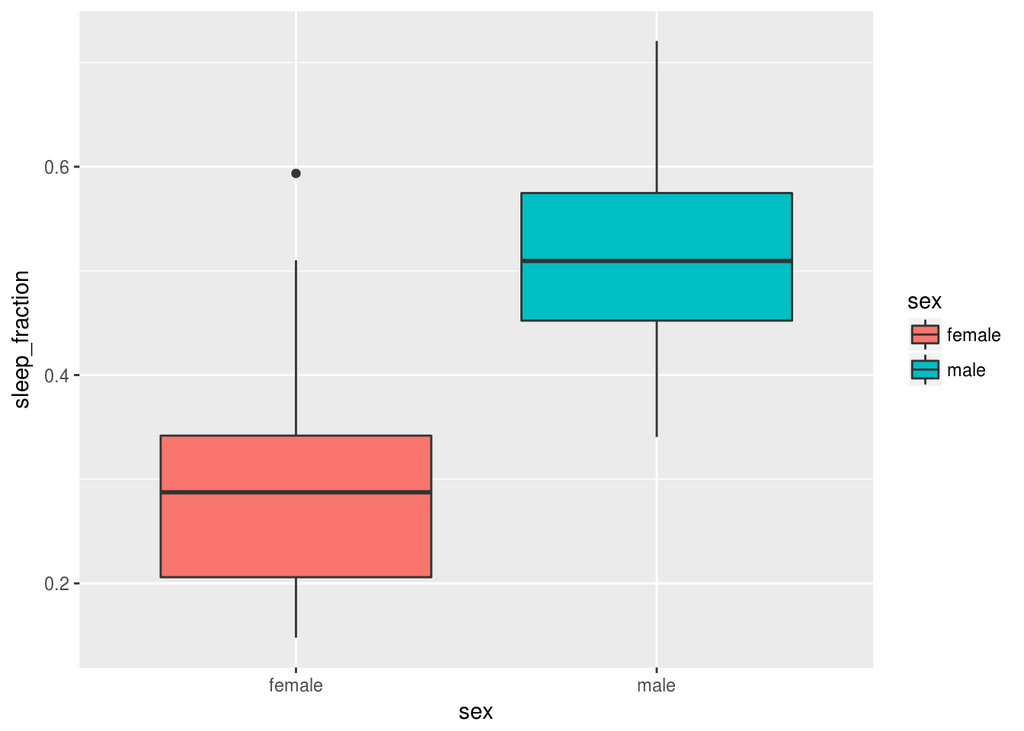

```r
# a graph using ggplot
ggplot(summary_dt, aes(sex,sleep_fraction, fill=sex)) + geom_boxplot()
```

## Conventions

Time is **always** named `t`, and expressed in **seconds**. The time is always compared to a reference point. The reference time can be either the start of the experiment, or a time in the first day of the experiment (see tutorial on loading the data)

Distance units such as `x`, `y`, `w` and `h` variables are coordinates from the **top-left** of the region in which the animal was recorded. They are expressed as a **fraction of the region width**, *not* in pixels or cm.